# rna_seq_tutorial

Shaleigh Smith

4/29/2019

RNA-Seq Tutorial

This RNA-Seq tutorial is designed to give you an insight into how to download data from the Sequence Read Archive (SRA), run quality control, trimming, and alignments on the command line, and analyze the results using DESeq2.

This tutorial was made to be run on a high-throughput computing cluster with SLURM job manager. This can be done on your own system if the necessary software is installed. Please note that some of the steps are computationally heavy and will take a longer time on your local system.

We will be working with lung adenocarcinoma RNA-Seq data obtained from:

Seo JS, Ju YS, Lee WC, Shin JY et al. The transcriptional landscape and mutational profile of lung adenocarcinoma. Genome Res 2012 Nov;22(11):2109-19. PMID: 22975805 https://www.ncbi.nlm.nih.gov/geo/query/acc.cgi?acc=GSE40419

This includes paired normal and tumor samples. We will only be using a small subset of the samples, though the entire dataset is available for download. The first part of this tutorial will explain how to write the script for all data pre-processing. The second part is a simple workflow through DESeq2 to identify up and down regulated genes between normal and tumor samples.

First we will be creating a custom script to:

1. Download the RNA-Seq Datasets & Human Genome
2. Check the quality of the read
3. Trim the reads for low quality and adapters (if needed)
4. Align the reads to the reference genome
5. Convert and sort file formats
6. Create a feature counts matrix

Login to the cluster and create a new directory for this tutorial. This is where all of the files will be located:

#### mkdir rna_seq_tutorial

Open up a text editor in the new file (I use nano) and we will begin to write the first script

#### nano

Create a submitter script. This will submit you script for you and run the following tasks on each dataset in parallel.

See submitter.txt in file (or below)

#### #SBATCH –job-name=job_submitter ### name of job

#### #SBATCH –nodes=1 ### number of nodes to run on

#### #SBATCH –mem=200MB ### memory

#### #SBATCH –time=1:00:00 ### time

#### #SBATCH –error=job_sub_error.txt ### output error file

#### #SBATCH –output=job_sub_stdout.txt ### output standard file

#### sbatch –array=1 rna_seq_script.sh ERX140427 LC_C1

#### sbatch –array=1 rna_seq_script.sh ERX140428 LC_C2

#### sbatch –array=1 rna_seq_script.sh ERX140429 LC_C3

#### sbatch –array=1 rna_seq_script.sh ERX140431 LC_C5

#### sbatch –array=1 rna_seq_script.sh ERX140350 LC_C1_nor

#### sbatch –array=1 rna_seq_script.sh ERX140351 LC_C2_nor

#### sbatch –array=1 rna_seq_script.sh ERX140352 LC_C3_nor

#### sbatch –array=1 rna_seq_script.sh ERX140353 LC_C5_nor

Save this as submitter.sh

Open a new empty text file and treate a header for your rna script:

#### #SBATCH –job-name=rna_seq ### Job name

#### #SBATCH –mail-type=END,FAIL ### Mail events (NONE, BEGIN, END, FAIL, ALL)

#### #SBATCH –mail-user=name.last@school.org ### Where to send mail

#### #SBATCH –ntasks=4 ### Run on a 4 CPU

#### #SBATCH –mem=64gb ### Job memory request

#### #SBATCH –time=12:00:00 ### Time limit hrs:min:sec

#### #SBATCH –output=./rna_seq_%j.log ### Standard output and error log

#### #SBATCH -p cpu_short ### Node

Download the Human Genome (hg38)

#### wget ftp://igenome:G3nom3s4u@ussd-ftp.illumina.com/Homo_sapiens/UCSC/hg38/Homo_sapiens_UCSC_hg38.tar.gz

#### tar -zxvf Homo_sapiens_UCSC_hg38.tar.gz

Import modules

#### module load sratoolkit/2.9.1

#### module load fastqc/0.11.7

#### module load trimgalore/0.5.0

#### module load python/cpu/2.7.15-ES ## CutAdapt is hidden in here

#### module load bbmap/38.25

#### module load samtools/1.9

#### module load subread/1.6.3

Download Data from the SRA

#### fastq-dump ${1} –split-files –gzip -O ./

Remove fastq-dump directory

#### rm -r ~/ncbi

Rename files

#### mv ./ ${1}_1*fastq.gz ./ ${2}_1.fastq.gz

#### mv ./ ${1}_2*fastq.gz ./ ${2}_2.fastq.gz

Trim and run FASTQC

#### trim_galore –q 30 –phred33 -o ./ –paired –fastqc ./ ${2}_1.fastq.gz ./ ${2}_2.fastq.gz

Align reads to reference genome

#### bbmap.sh -Xmx26G ref=./Homo_sapiens/UCSC/hg38/Sequence/WholeGenomeFasta/genome.fa

#### in= ./ ${2}_val_1.fq.gz in2= ./ ${2}_val_2.fq.gz outm= ./ ${2}.sam minid=0.90 ambiguous=random nodisk

Convert SAM file to BAM file and sort

#### samtools view -S -b ${2}.sam > ${2}.bam

#### samtools sort ${2}.bam -o ${2}_sorted.bam

There is a large variety of flags that can be used for feature counts. In this case we will be more stringent with the following parameters.

The input is specified as reversely stranded (-s 2) and paired end (-p). The fragment length is checked (-P) and only the fragments that have both ends successfully aligned are counted (-B). Chimeric fragments are ignored (-C) as are duplicates (–ignoreDup). Finally, only primary alignments are counted (–primary) and the counts are based on gene_id (-g).

Create a feature counts matrix

#### featureCounts -s 2 -p -B -C -P –ignoreDup –primary -a ./Homo_sapiens/UCSC/hg38/Annotation/Genes.gencode/genes.gtf -g gene_id -o $ {2} -feature-counts ./${2}_sorted.bam

Save the script as rna_seq_script.sh

The final script should look include all of these commands. See ‘rna_seq_script.sh’ in the tutorial file for the final example.

To run your submitter (this will submit all 8 scripts, one for each dataset)

#### ./submitter.sh

Check the output. It should include these files for each dataset:

1. LC_C1_1.fastq.gz
2. LC_C1_1.fastq.gz_trimming_report.txt
3. LC_C1_1_val_1_fastqc.html
4. LC_C1_1_val_1_fastqc.zip
5. LC_C1_1_val_1.fq.gz
6. LC_C1_2.fastq.gz
7. LC_C1_2.fastq.gz_trimming_report.txt
8. LC_C1_2_val_2_fastqc.html
9. LC_C1_2_val_2_fastqc.zip
10. LC_C1_2_val_2.fq.gz
11. LC_C1.bam
12. LC_C1_feature_counts
13. LC_C1_feature_counts.summary

Copy the feature counts files to your local directory. You can do this using a command or an application like FileZilla.

The downstream analysis will be done in R using DESeq2. Open up a new script in R - I prefer using an R Markdown file so that you can visualize the results for each step.

The general workflow is as follows:

1. Import count matrices
2. Normalization
3. Transformation
4. LFC shrinkage
5. Data exploration (sample relatedness)
6. Difference gene expression analysis

```r
# Load Libraries
library(tidyverse)
library(plyr)
library(dplyr)
library(DESeq2)
#library(purrr)
library(ComplexHeatmap)
library(circlize)
library(ggplot2)
library(ggfortify)
#library(vsn)
library(AnnotationDbi)
library(org.Hs.eg.db)
library(genefilter)
library(biomaRt)
library(data.table)
#library(IHW)
#library(VennDiagram)
#library(gridExtra)

# Not all of these are required - this depends on how you choose to visualize your results
```

```r
### Import & clean gene count files

count_1 <- read.table("./data/LC_C1_nor_feature_counts", header=TRUE)
colnames(count_1)[c(1, 7)] <- c("gene_id", "LC_C1_nor")
count_1 <- dplyr::select(count_1, gene_id, LC_C1_nor)
count_1$gene_id <- substring(count_1$gene_id, 1, 15)

count_2 <- read.table("./data/LC_C1_feature_counts", header=TRUE)
colnames(count_2)[c(1, 7)] <- c("gene_id", "LC_C1")
count_2 <- dplyr::select(count_2, gene_id, LC_C1)
count_2$gene_id <- substring(count_2$gene_id, 1, 15)

count_3 <- read.table("./data/LC_C2_nor_feature_counts", header=TRUE)
colnames(count_3)[c(1, 7)] <- c("gene_id", "LC_C2_nor")
count_3 <- dplyr::select(count_3, gene_id, LC_C2_nor)
count_3$gene_id <- substring(count_3$gene_id, 1, 15)

count_4 <- read.table("./data/LC_C2_feature_counts", header=TRUE)
colnames(count_4)[c(1, 7)] <- c("gene_id", "LC_C2")
count_4 <- dplyr::select(count_4, gene_id, LC_C2)
count_4$gene_id <- substring(count_4$gene_id, 1, 15)

count_5 <- read.table("./data/LC_C3_nor_feature_counts", header=TRUE)
colnames(count_5)[c(1, 7)] <- c("gene_id", "LC_C3_nor")
count_5 <- dplyr::select(count_5, gene_id, LC_C3_nor)
count_5$gene_id <- substring(count_5$gene_id, 1, 15)

count_6 <- read.table("./data/LC_C3_feature_counts", header=TRUE)
colnames(count_6)[c(1, 7)] <- c("gene_id", "LC_C3")
count_6 <- dplyr::select(count_6, gene_id, LC_C3)
count_6$gene_id <- substring(count_6$gene_id, 1, 15)

count_7 <- read.table("./data/LC_C5_nor_feature_counts", header=TRUE)
colnames(count_7)[c(1, 7)] <- c("gene_id", "LC_C5_nor")
count_7 <- dplyr::select(count_7, gene_id, LC_C5_nor)
count_7$gene_id <- substring(count_7$gene_id, 1, 15)

count_8 <- read.table("./data/LC_C5_feature_counts", header=TRUE)
colnames(count_8)[c(1, 7)] <- c("gene_id", "LC_C5")
count_8 <- dplyr::select(count_8, gene_id, LC_C5)
count_8$gene_id <- substring(count_8$gene_id, 1, 15)

# You can also create a function to do this if you have a large amount of files
```

```r
### Join all gene count files into one data frame
feature_counts <- join_all(list(count_1, count_3, count_5, count_7, count_2, count_4,
                       count_6, count_8), by = "gene_id", type = "full")
# Write out table for later analysis
write.table(feature_counts, file = "feature_counts.txt", quote=FALSE, sep='\t', row.names = FALSE)
```

```r
# Read in feature counts
deseq_counts <- read.table("feature_counts.txt", header=TRUE, row.names=1)
as_tibble(deseq_counts)
```

```
## # A tibble: 66,023 x 8
##    LC_C1_nor LC_C2_nor LC_C3_nor LC_C5_nor LC_C1 LC_C2 LC_C3 LC_C5
##        <int>     <int>     <int>     <int> <int> <int> <int> <int>
##  1         0         0         0         0     0     0     0     0
##  2         0         0         0         0     0     0     0     0
##  3         0         0         0         0     0     0     0     0
##  4         0         0         0         0     0     0     0     0
##  5         0         0         0         0     0     0     0     0
##  6         0         0         0         0     0     0     0     0
##  7         0         0         0         0     0     0     0     0
##  8         0         0         0         0     0     0     0     0
##  9         0         0         0         0     0     0     0     0
## 10         0         0         0         0     0     0     0     0
## # … with 66,013 more rows
```

```r
# Create DeSeq dataset
samples <- data.frame(row.names = c("LC_C1_nor", "LC_C2_nor", "LC_C3_nor", "LC_C5_nor",
                                    "LC_C1", "LC_C2", "LC_C3", "LC_C5"),
                      sample = as.factor(c(rep("normal", 4),
                                           rep("tumor", 4))))
deseq_df <- DESeqDataSetFromMatrix(countData = deseq_counts, colData = samples,
                                   design = ~ sample)

# Remove genes that do not have counts greater than 2 in at least 2 of the datasets (columns)
deseq_df <- deseq_df[rowSums(counts(deseq_df) >= 2) >= 2]

# Confirm that all samples are labelled correctly
as.data.frame(colData(deseq_df))
```

```
##           sample
## LC_C1_nor normal
## LC_C2_nor normal
## LC_C3_nor normal
## LC_C5_nor normal
## LC_C1      tumor
## LC_C2      tumor
## LC_C3      tumor
## LC_C5      tumor
```

```r
### Exploratory data analysis of DESeq matrix with transformation

# Estimate size factors
# The size factor is the median ratio of the sample over a pseudosample: for each gene, the geometric mean of all samples
deseq_eda <- estimateSizeFactors(deseq_df)

# Apply regularized-logarithm transformation
rld <- rlog(deseq_eda, blind = FALSE)

# Apply variance stabilizing transformation
vsd <- vst(deseq_eda, blind = FALSE)

# Create new data frame three normalization methods for all samples
deseq_eda <- bind_rows(
  as_data_frame(log2(counts(deseq_eda, normalized=TRUE)[, (1:8)])) %>%
         mutate(transform = "log2(x + 1)"),
  as_data_frame(assay(vsd)[, (1:8)]) %>% mutate(transform = "vst"),
  as_data_frame(assay(rld)[, (1:8)]) %>% mutate(transform = "rlog"))
```

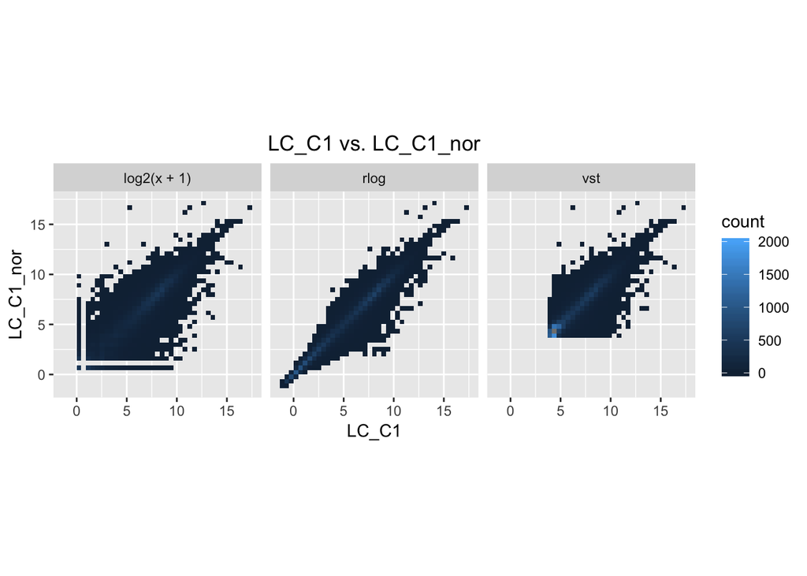

```r
# Compare transformation visually
ggplot(deseq_eda, aes(x = LC_C1, y = LC_C1_nor)) +
  geom_bin2d(bins = 40) +
  coord_fixed() +
  facet_grid( . ~ transform) +
  scale_fill_continuous(limits = c(0, 2000), breaks = seq(0, 2000, by = 500)) +
  ggtitle("LC_C1 vs. LC_C1_nor") + theme(plot.title = element_text(hjust = 0.5))
```

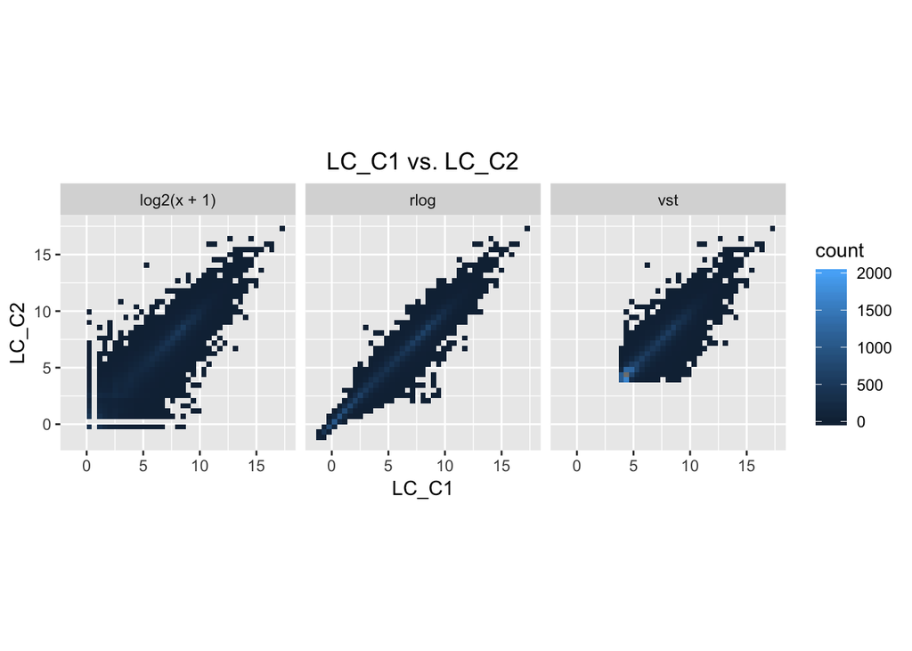

```r
ggplot(deseq_eda, aes(x = LC_C1, y = LC_C2)) +
  geom_bin2d(bins = 40) +
  coord_fixed() +
  facet_grid( . ~ transform) +
  scale_fill_continuous(limits = c(0, 2000), breaks = seq(0, 2000, by = 500)) +
  ggtitle("LC_C1 vs. LC_C2") + theme(plot.title = element_text(hjust = 0.5))
```

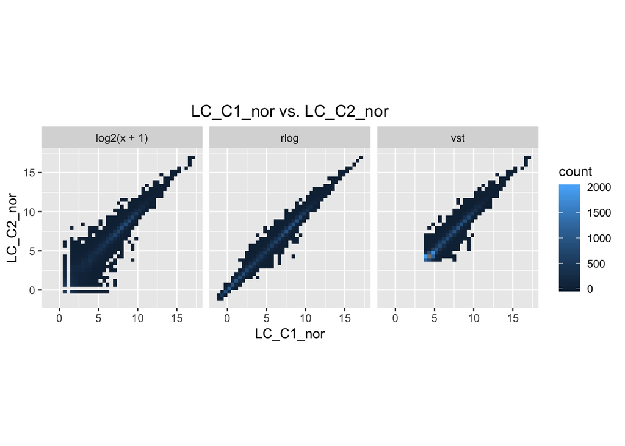

```r
ggplot(deseq_eda, aes(x = LC_C1_nor, y = LC_C2_nor)) +
  geom_bin2d(bins = 40) +
  coord_fixed() +
  facet_grid( . ~ transform) +
  scale_fill_continuous(limits = c(0, 2000), breaks = seq(0, 2000, by = 500)) +
  ggtitle("LC_C1_nor vs. LC_C2_nor") + theme(plot.title = element_text(hjust = 0.5))
```

```r
### Exploratory data analysis of DESeq matrix with sample comparison
# This will asses overall similarity between samples
# As shown in the above plots this similarity might not be as expected

# Calculate the euclidean distance between samples
deseq_distance <- dist(t(assay(rld)))
deseq_distance
```

```
##           LC_C1_nor LC_C2_nor LC_C3_nor LC_C5_nor     LC_C1     LC_C2
## LC_C2_nor  51.13731
## LC_C3_nor  71.58464  76.42172
## LC_C5_nor  58.77143  68.19637  59.83348
## LC_C1     111.80209 117.40755 127.37008 109.89254
## LC_C2      88.31594  83.16705 104.76186  89.32528 101.85952
## LC_C3      94.82329  99.30413  93.51278  86.65237 107.99699  87.75215
## LC_C5      71.64668  75.54139  98.42465  72.55669  91.21665  73.96552
##               LC_C3
## LC_C2_nor
## LC_C3_nor
## LC_C5_nor
## LC_C1
## LC_C2
## LC_C3
## LC_C5      83.17266
```

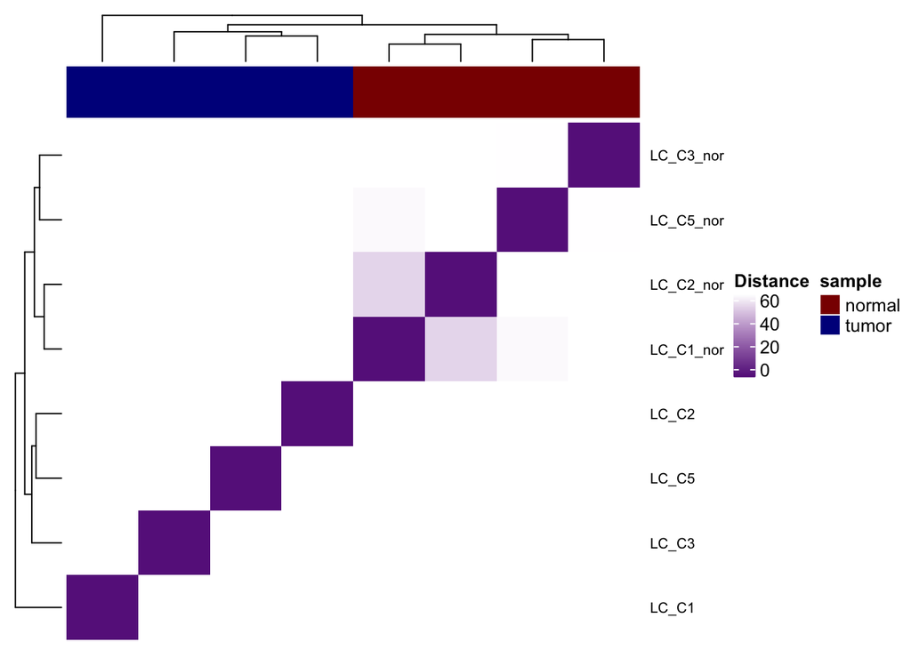

```r
# Create annotation for the heatmap
deseq_annotation <- as.data.frame(as.factor(c(rep("normal", 4),
                                              rep("tumor", 4))))
colnames(deseq_annotation)[1] <- c("sample")
deseq_ha <- HeatmapAnnotation(df = deseq_annotation,
                              col = list(sample = c("normal" = "darkred",
                                                    "tumor" = "darkblue")))

# Make dataframe a matrix for heatmpap
deseq_heatmap <- as.matrix(deseq_distance)

# Visualize with heatmap
deseq_heat <- Heatmap(deseq_heatmap,
                   top_annotation = deseq_ha,
                   show_column_names = F,
                   show_row_names = T,
                   cluster_rows = T,
                   cluster_columns = T,
                   clustering_method_columns = 'complete',
                   clustering_method_rows = "complete",
                   row_names_gp = gpar(fontsize = 8),
                   top_annotation_height = unit(1, "cm"),
                   heatmap_legend_param = list(title = "Distance"),
                   col = colorRamp2(c(0, 60), c("darkorchid4", "white")))

deseq_heat
```

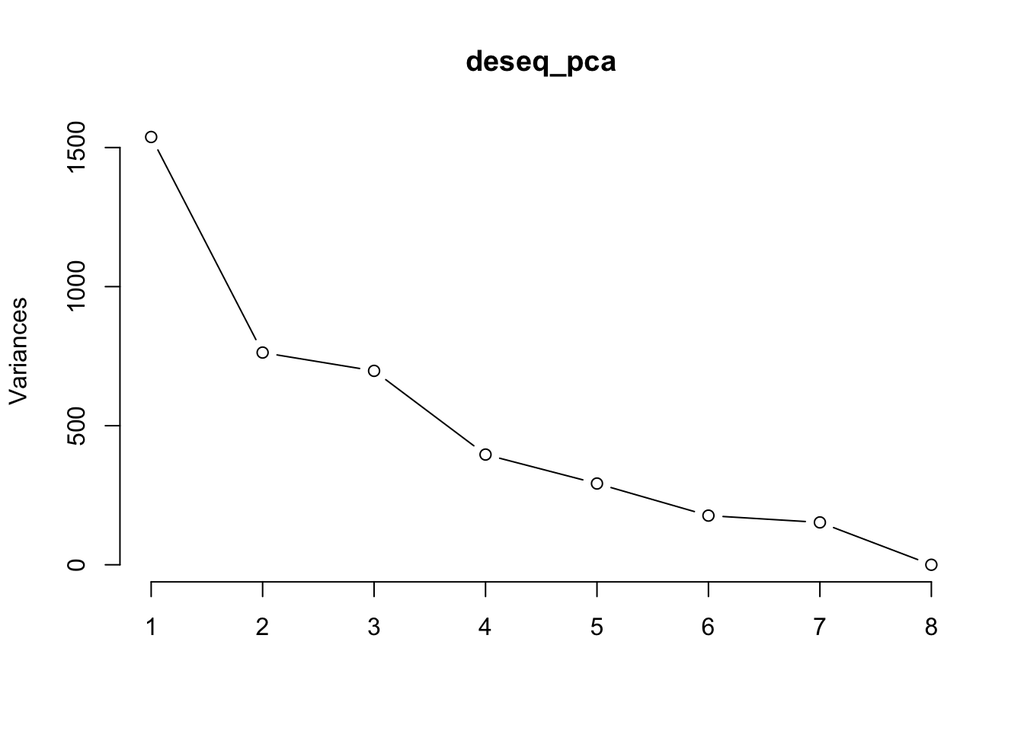

```r
### Compare with PCA
# visualize screeplot and autoplotted pca for reference
deseq_pca <-prcomp(t(assay(rld)))
screeplot(deseq_pca, type='lines')
```

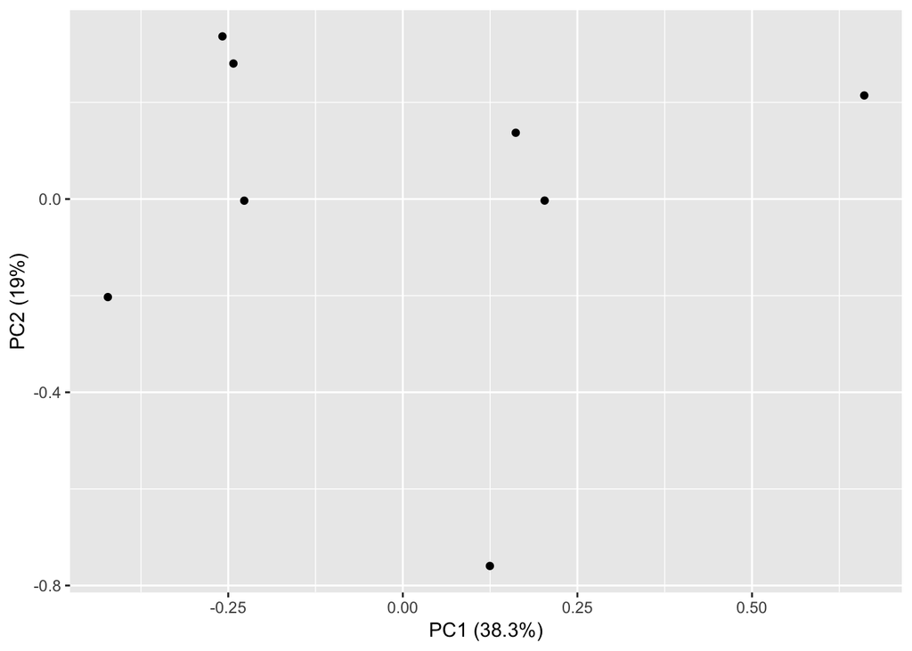

```r
autoplot(deseq_pca)
```

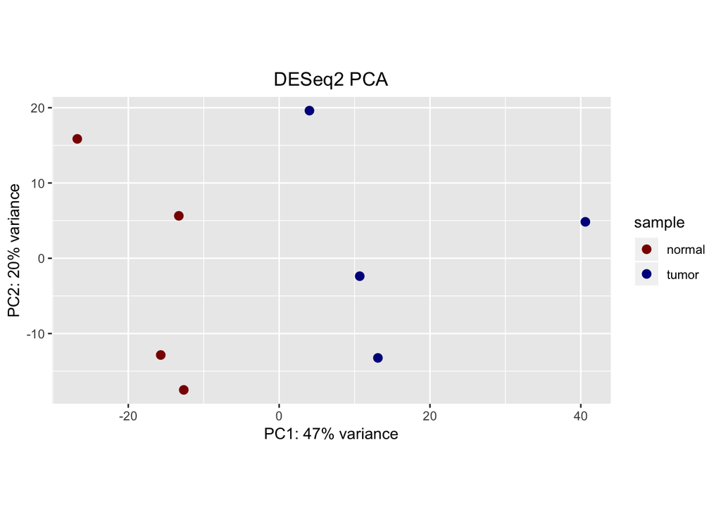

```r
# Create PCA object to be plotted with ggplot
plot_pca <- plotPCA(rld, intgroup = c("sample"), returnData = TRUE)

# Calculate and round variance for plotting
percentVar <- round(100 * attr(plot_pca, "percentVar"))

# Plot PCA
deseq_pca_1 <- ggplot(plot_pca, aes(x = PC1, y = PC2, color = sample)) +
  geom_point(size = 2.5) +
  xlab(paste0("PC1: ", percentVar[1], "% variance")) +
  ylab(paste0("PC2: ", percentVar[2], "% variance")) +
  coord_fixed() +
  scale_color_manual(values = c("darkred", "darkblue")) +
  ggtitle("DESeq2 PCA") +
  theme(plot.title = element_text(hjust = 0.5))

deseq_pca_1
```

```r
# Make sure that normal is the first level in the sample factor
# This is to ensure the log2 fold change is calculated over the control (when results are called at random)
deseq_df$sample <- relevel(deseq_df$sample, "normal")

# Check to insure all samples are correct
as.data.frame(colData(deseq_df))
```

```
##           sample
## LC_C1_nor normal
## LC_C2_nor normal
## LC_C3_nor normal
## LC_C5_nor normal
## LC_C1      tumor
## LC_C2      tumor
## LC_C3      tumor
## LC_C5      tumor
```

```r
# Run the DESeq analysis against raw counts
deseq_analysis <- DESeq(deseq_df)
results(deseq_analysis)
```

```
## log2 fold change (MLE): sample tumor vs normal
## Wald test p-value: sample tumor vs normal
## DataFrame with 30557 rows and 6 columns
##                          baseMean     log2FoldChange             lfcSE
##                         <numeric>          <numeric>         <numeric>
## ENSG00000223972  1.68678080119063  0.373067270532259  1.30801336507415
## ENSG00000227232  106.785897388606 -0.123814303235241 0.247842551198888
## ENSG00000278267  2.90549296286756  0.578243632807279 0.964933286611087
## ENSG00000238009  6.28465034791619   1.59827051726701 0.999832447097984
## ENSG00000233750  11.8326204944221  0.971658963876848 0.637663848553708
## ...                           ...                ...               ...
## ENSG00000226941 0.920694068293952  0.858655189686039  1.92502767029336
## ENSG00000243040  1.27785825900166   1.02093174292253  2.26952324860404
## ENSG00000279274  7.97506099521841  0.389941281441537 0.596155494954517
## ENSG00000279115  7.99052746744599 0.0165357694987496 0.614680017599215
## ENSG00000233652 0.630039498334676 -0.501456139552646  3.08257603012088
##                               stat            pvalue              padj
##                          <numeric>         <numeric>         <numeric>
## ENSG00000223972  0.285216711460063 0.775478117975857                NA
## ENSG00000227232 -0.499568385801041 0.617379023026149 0.831351103379055
## ENSG00000278267  0.599257628305176 0.549001098684654                NA
## ENSG00000238009   1.59853835700771  0.10992321605469 0.350627774351723
## ENSG00000233750   1.52377928603084 0.127563855659837 0.382660102902234
## ...                            ...               ...               ...
## ENSG00000226941  0.446048232415893 0.655562405749828                NA
## ENSG00000243040   0.44984414394102 0.652822825139448                NA
## ENSG00000279274  0.654093243695233 0.513051734049477  0.76745275679686
## ENSG00000279115 0.0269014267998073 0.978538355508756  0.99177619297538
## ENSG00000233652 -0.162674378394158 0.870774821321036                NA
```

```r
# Call results
deseq_results <- results(deseq_analysis, contrast = c("sample", "normal", "tumor"))
deseq_results
```

```
## log2 fold change (MLE): sample normal vs tumor
## Wald test p-value: sample normal vs tumor
## DataFrame with 30557 rows and 6 columns
##                          baseMean      log2FoldChange             lfcSE
##                         <numeric>           <numeric>         <numeric>
## ENSG00000223972  1.68678080119063  -0.373067270532259  1.30801336507415
## ENSG00000227232  106.785897388606   0.123814303235241 0.247842551198888
## ENSG00000278267  2.90549296286756  -0.578243632807279 0.964933286611087
## ENSG00000238009  6.28465034791619   -1.59827051726701 0.999832447097984
## ENSG00000233750  11.8326204944221  -0.971658963876848 0.637663848553708
## ...                           ...                 ...               ...
## ENSG00000226941 0.920694068293952  -0.858655189686039  1.92502767029336
## ENSG00000243040  1.27785825900166   -1.02093174292253  2.26952324860404
## ENSG00000279274  7.97506099521841  -0.389941281441537 0.596155494954517
## ENSG00000279115  7.99052746744599 -0.0165357694987496 0.614680017599215
## ENSG00000233652 0.630039498334676   0.501456139552646  3.08257603012088
##                                stat            pvalue              padj
##                           <numeric>         <numeric>         <numeric>
## ENSG00000223972  -0.285216711460063 0.775478117975857                NA
## ENSG00000227232   0.499568385801041 0.617379023026149 0.831351103379055
## ENSG00000278267  -0.599257628305176 0.549001098684654                NA
## ENSG00000238009   -1.59853835700771  0.10992321605469 0.350627774351723
## ENSG00000233750   -1.52377928603084 0.127563855659837 0.382660102902234
## ...                             ...               ...               ...
## ENSG00000226941  -0.446048232415893 0.655562405749828                NA
## ENSG00000243040   -0.44984414394102 0.652822825139448                NA
## ENSG00000279274  -0.654093243695233 0.513051734049477  0.76745275679686
## ENSG00000279115 -0.0269014267998073 0.978538355508756  0.99177619297538
## ENSG00000233652   0.162674378394158 0.870774821321036                NA
```

```r
# Review Comparisons
mcols(deseq_results, use.names = TRUE)
```

```
## DataFrame with 6 rows and 2 columns
##                        type                                    description
##                 <character>                                    <character>
## baseMean       intermediate      mean of normalized counts for all samples
## log2FoldChange      results log2 fold change (MLE): sample normal vs tumor
## lfcSE               results         standard error: sample normal vs tumor
## stat                results         Wald statistic: sample normal vs tumor
## pvalue              results      Wald test p-value: sample normal vs tumor
## padj                results                           BH adjusted p-values
```

```r
### Review Summary
summary(deseq_results, alpha = 0.01)
```

```
##
## out of 30557 with nonzero total read count
## adjusted p-value < 0.01
## LFC > 0 (up)       : 530, 1.7%
## LFC < 0 (down)     : 696, 2.3%
## outliers [1]       : 186, 0.61%
## low counts [2]     : 6517, 21%
## (mean count < 4)
## [1] see 'cooksCutoff' argument of ?results
## [2] see 'independentFiltering' argument of ?results
```

```r
### Plot p-values for distribution check

# Calculate row means across samples
mean_norm <-  rowMeans(counts(deseq_analysis, normalized=TRUE)[, deseq_analysis$sample == "normal"])
mea_tumor <-  rowMeans(counts(deseq_analysis, normalized=TRUE)[, deseq_analysis$sample == "tumor"])

### Normal vs. Tumor
# Log Fold change
lfc_comp <- lfcShrink(deseq_analysis, contrast = c("sample", "normal", "tumor"))
```

```
## using 'normal' for LFC shrinkage, the Normal prior from Love et al (2014).
## additional priors are available via the 'type' argument, see ?lfcShrink for details
```

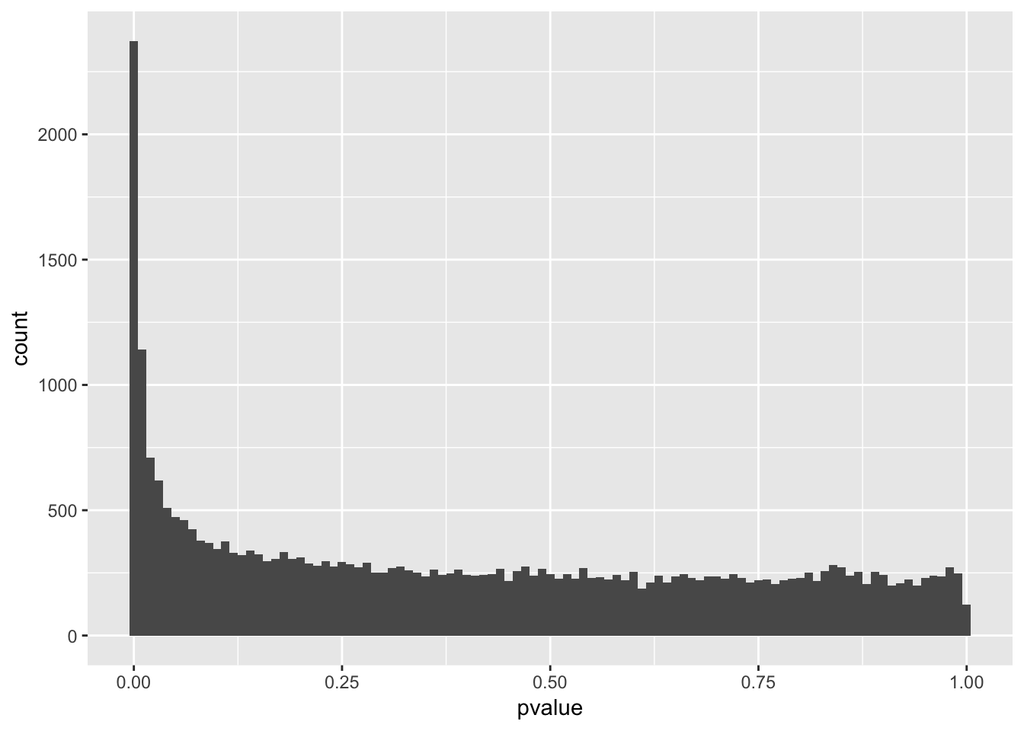

```r
# add row names to log fold change data frame
lfc_comp <-  cbind(as.data.frame(lfc_comp), mean_norm, mea_tumor)

# Map gene names and ids
lfc_comp$symbol <- mapIds(org.Hs.eg.db, keys=row.names(lfc_comp),
                             column="SYMBOL", keytype="ENSEMBL", multiVals="first")
lfc_comp$entrez <- mapIds(org.Hs.eg.db, keys=row.names(lfc_comp),
                             column="ENTREZID", keytype="ENSEMBL", multiVals="first")
# Plot histogram to review distribution
ggplot(data = lfc_comp, mapping = aes(x = pvalue)) + geom_histogram(binwidth = 0.01)
```

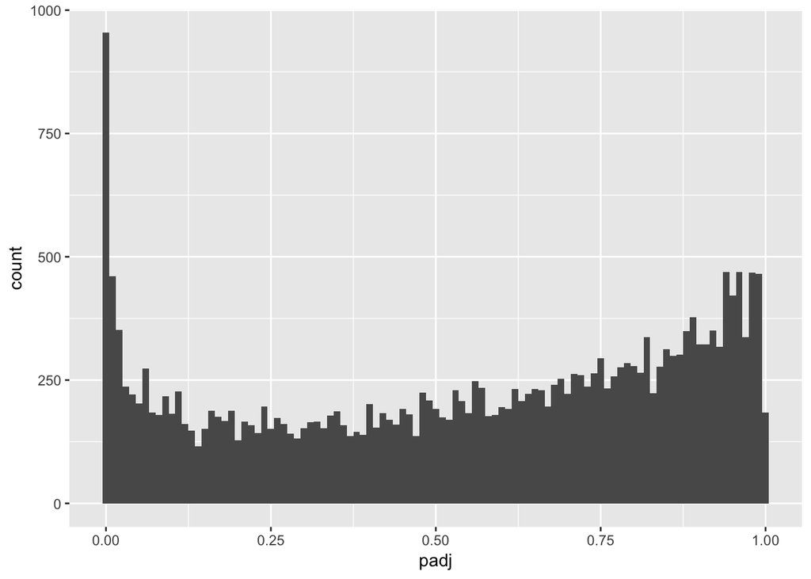

```r
ggplot(data = lfc_comp, mapping = aes(x = padj)) + geom_histogram(binwidth = 0.01)
```

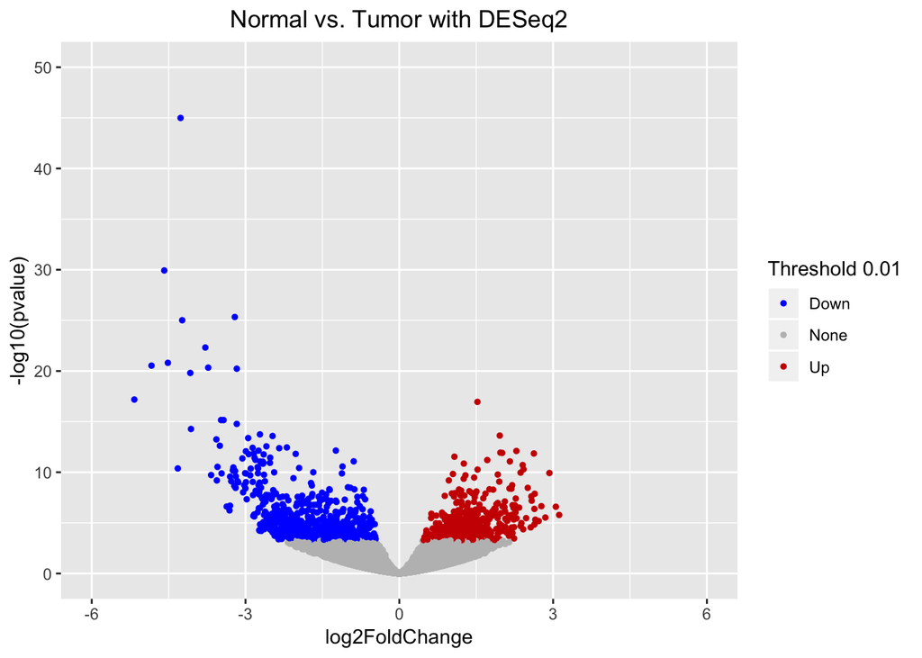

```r
#### Volcano Plots

# Create up, none, down labels for color then plot

# Control 1 vs. Expression
lfc_comp <- lfc_comp %>%
  mutate(threshold = ifelse((log2FoldChange >= 0 & padj < 0.01), "up_sig",
                            ifelse((log2FoldChange <= 0 & padj < 0.01) ,
                                   "down_sig", "not_sig")))
lfc_comp$threshold[is.na(lfc_comp$threshold)] <- "not_sig"

des_vol <- ggplot(lfc_comp, aes(x = log2FoldChange, y = -log10(pvalue))) +
  geom_point(aes(colour = threshold), size=1) +
  ggtitle("Normal vs. Tumor with DESeq2") +
  theme(plot.title = element_text(hjust = 0.5)) +
  ylim(0,50) + xlim(-6,6) +
  scale_colour_manual(values=c("blue", "grey", "red3"),
                       name="Threshold 0.01",
                       breaks=c("down_sig", "not_sig", "up_sig"),
                       labels=c("Down", "None", "Up"))

des_vol
```

```r
#### Heatmaps with top variable genes

# Normal vs. Tumor
# Transform with regularized log
rld <- rlog(deseq_analysis)
#assay(rld)

# Order genes then filter for the top 25
top_genes <- head(order(rowMeans(assay(rld)), decreasing = TRUE), 30)
as_tibble(top_genes)
```

```
## # A tibble: 30 x 1
##    value
##    <int>
##  1 29442
##  2  3634
##  3  3636
##  4 29454
##  5 29430
##  6 16674
##  7 27343
##  8 29458
##  9 29276
## 10 29449
## # … with 20 more rows
```

```r
deseq_genes <- assay(rld)[top_genes, ]

# Calculate distances from the mean for clearer heatmap
deseq_genes <- (deseq_genes - rowMeans(deseq_genes))

# Connect to ensemble database and label gene ids with gene symbol
mart <- useMart("ENSEMBL_MART_ENSEMBL","hsapiens_gene_ensembl")
gene_symbol <- getBM(c("hgnc_symbol","ensembl_gene_id"), "ensembl_gene_id", row.names(deseq_genes), mart)

row.names(deseq_genes)[match(gene_symbol[,2], row.names(deseq_genes))] <- gene_symbol[,1]

as_tibble(deseq_genes)
```

```
## # A tibble: 30 x 8
##    LC_C1_nor LC_C2_nor LC_C3_nor LC_C5_nor   LC_C1   LC_C2  LC_C3  LC_C5
##        <dbl>     <dbl>     <dbl>     <dbl>   <dbl>   <dbl>  <dbl>  <dbl>
##  1   -0.227    -0.166    -0.251     -0.300  0.284   0.307   0.172 0.181
##  2    0.392     0.277     0.363      0.263 -2.10   -0.0445  0.127 0.719
##  3    0.527     0.445     0.488      0.279 -2.42   -0.0617  0.182 0.560
##  4   -0.378    -0.0726   -0.122     -0.406  0.340   0.154   0.262 0.222
##  5   -0.220    -0.203    -0.275     -0.270  0.258   0.110   0.353 0.246
##  6    0.297     0.0860    0.375      0.284 -2.41    0.139   0.992 0.241
##  7    0.777     0.524     1.02       0.720 -2.98   -0.922   0.852 0.0124
##  8   -0.125     0.109     0.129     -0.303  0.188  -0.0559 -0.154 0.212
##  9   -0.0773   -0.0794   -0.0308    -0.287 -0.0937  0.0410  0.435 0.0931
## 10   -0.298    -0.0809   -0.230     -0.258  0.0694  0.187   0.441 0.169
## # … with 20 more rows
```

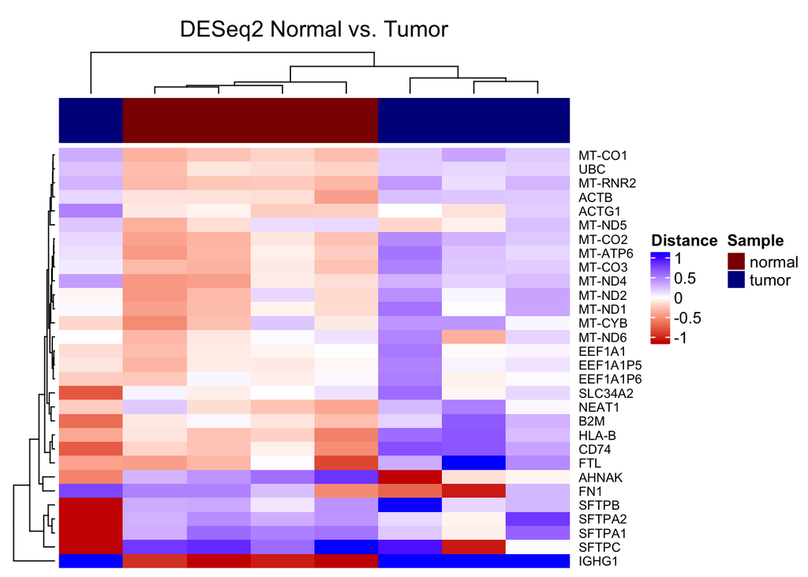

```r
# Create Annotation
sample_annotation <- as.data.frame(colData(rld)[, c("sample")])
colnames(sample_annotation)[1] <- "Sample"
sample_ha <- HeatmapAnnotation(df = sample_annotation,
                               col = list(Sample = c("normal" = "darkred",
                                                     "tumor" = "darkblue")))

# Create Heatmap
deseq_heat <- Heatmap(deseq_genes,
                   top_annotation = sample_ha,
                   show_column_names = F,
                   show_row_names = T,
                   cluster_rows = T,
                   cluster_columns = T,
                   clustering_method_columns = 'complete',
                   clustering_method_rows = "complete",
                   row_names_gp = gpar(fontsize = 8),
                   top_annotation_height = unit(1, "cm"),
                   heatmap_legend_param = list(title = "Distance"),
                   col = colorRamp2(c(-1, 0, 1), c("red3", "white", "blue")),
                   column_title = "DESeq2 Normal vs. Tumor")

deseq_heat
```

```r
# Add column for upregulated vs. downregulated
lfc_comp$expression <- NA
lfc_comp$expression[lfc_comp$log2FoldChange > 0 ] <- "up"
lfc_comp$expression[lfc_comp$log2FoldChange < 0 ] <- "down"
setDT(lfc_comp, keep.rownames = TRUE)[]
```

```
##                     rn    baseMean log2FoldChange     lfcSE        stat
##     1: ENSG00000223972   1.6867808    -0.17239324 0.6031239 -0.28521671
##     2: ENSG00000227232 106.7858974     0.11882099 0.2378580  0.49956839
##     3: ENSG00000278267   2.9054930    -0.35242026 0.5891733 -0.59925763
##     4: ENSG00000238009   6.2846503    -0.94407489 0.5923546 -1.59853836
##     5: ENSG00000233750  11.8326205    -0.75895348 0.4979941 -1.52377929
##    ---
## 30553: ENSG00000226941   0.9206941    -0.24909309 0.5469515 -0.44604823
## 30554: ENSG00000243040   1.2778583    -0.22761615 0.5045542 -0.44984414
## 30555: ENSG00000279274   7.9750610    -0.31343477 0.4793809 -0.65409324
## 30556: ENSG00000279115   7.9905275    -0.01315988 0.4885462 -0.02690143
## 30557: ENSG00000233652   0.6300395     0.07103459 0.4123289  0.16267438
##           pvalue      padj   mean_norm   mea_tumor       symbol    entrez
##     1: 0.7754781        NA   1.4777680   1.8957936      DDX11L1 100287102
##     2: 0.6173790 0.8313511 111.4053993 102.1663954       WASH7P    653635
```

[output cut: 21 more lines]

```r
colnames(lfc_comp)[1] <- "gene_id"
head(lfc_comp)
```

```
##            gene_id   baseMean log2FoldChange     lfcSE       stat
## 1: ENSG00000223972   1.686781     -0.1723932 0.6031239 -0.2852167
## 2: ENSG00000227232 106.785897      0.1188210 0.2378580  0.4995684
## 3: ENSG00000278267   2.905493     -0.3524203 0.5891733 -0.5992576
## 4: ENSG00000238009   6.284650     -0.9440749 0.5923546 -1.5985384
## 5: ENSG00000233750  11.832620     -0.7589535 0.4979941 -1.5237793
## 6: ENSG00000268903  74.771882     -0.2325216 0.3451100 -0.6737298
##       pvalue      padj  mean_norm  mea_tumor       symbol    entrez
## 1: 0.7754781        NA   1.477768   1.895794      DDX11L1 100287102
## 2: 0.6173790 0.8313511 111.405399 102.166395       WASH7P    653635
## 3: 0.5490011        NA   2.364188   3.446798    MIR6859-1 102466751
## 4: 0.1099232 0.3506278   3.158444   9.410856 LOC100996442 100996442
## 5: 0.1275639 0.3826601   8.033197  15.632043         <NA>      <NA>
## 6: 0.5004831 0.7580631  68.048584  81.495180         <NA>      <NA>
##    threshold expression
## 1:   not_sig       down
## 2:   not_sig         up
## 3:   not_sig       down
## 4:   not_sig       down
## 5:   not_sig       down
## 6:   not_sig       down
```

```r
# Filter out columns for significantly upregulated and downregulated genes
lfc_comp_final <- dplyr::select(lfc_comp, gene_id, symbol, log2FoldChange, padj, expression)
lfc_comp_final <- filter(lfc_comp_final, padj < 0.01)
lfc_comp_final <- lfc_comp_final[order(lfc_comp_final$padj),]
head(lfc_comp_final)
```

```
##             gene_id      symbol log2FoldChange         padj expression
## 785 ENSG00000211662        <NA>      -4.267441 2.442531e-41       down
## 745 ENSG00000100985        MMP9      -4.585407 1.401832e-26       down
## 375 ENSG00000232216        <NA>      -3.209421 3.709018e-22       down
## 351 ENSG00000211892        <NA>      -4.235352 5.761433e-22       down
## 810 ENSG00000159958   TNFRSF13C      -3.784348 2.298776e-19       down
## 746 ENSG00000204044 SLC12A5-AS1      -4.514869 6.196209e-18       down
```

```r
# Convert gene ids to gene symbol
mart <- useMart("ENSEMBL_MART_ENSEMBL","hsapiens_gene_ensembl")
gene_symbol <- getBM(c("hgnc_symbol","ensembl_gene_id"), "ensembl_gene_id", row.names(deseq_analysis), mart)

row.names(deseq_analysis)[match(gene_symbol[,2], row.names(deseq_analysis))] <- gene_symbol[,1]

### Filter and order dataframes
# State whether they are upregulated or downregulated
# Filter out columns for significantly upregulated and downregulated genes

# Top 30 expressed genes (by p-value adjusted)
top_30 <- as.data.frame(results(deseq_analysis))
top_30 <- top_30[order(top_30$padj),]
top_30 <- head(top_30, 30)
setDT(top_30, keep.rownames = TRUE)[]
```

```
##              rn    baseMean log2FoldChange     lfcSE      stat
##  1:    IGLV3-21   277.08286       4.568415 0.3218961 14.192200
##  2:        MMP9   315.45965       5.239273 0.4551948 11.509959
##  3:    IGHV3-43    95.96347       3.441615 0.3259720 10.558006
##  4:       IGHG4  3015.20917       4.867955 0.4640821 10.489428
##  5:   TNFRSF13C    62.49535       4.243224 0.4292432  9.885361
##  6: SLC12A5-AS1    93.36308       5.515119 0.5786538  9.530948
##  7:        SPP1  2239.18302       6.702812 0.7082086  9.464460
##  8:       MS4A1   280.52010       4.250920 0.4514387  9.416384
##  9:       CD79A   105.92410       3.462743 0.3687222  9.391198
## 10:      CXCL14   392.18954       4.852890 0.5224465  9.288778
## 11:      CXCL13   176.40483       8.117487 0.9414953  8.621909
## 12:       MT-TN   131.48338      -1.558411 0.1820458 -8.560543
## 13:       IGHG1 31560.10819       4.016756 0.4977376  8.070027
## 14:    IGLV3-27    80.88599       4.086417 0.5063069  8.071028
```

[output cut: 49 more lines]

```r
colnames(top_30)[1] <- "genes"

as_tibble(top_30)
```

```
## # A tibble: 30 x 7
##    genes       baseMean log2FoldChange lfcSE  stat   pvalue     padj
##    <chr>          <dbl>          <dbl> <dbl> <dbl>    <dbl>    <dbl>
##  1 IGLV3-21       277.            4.57 0.322 14.2  1.02e-45 2.44e-41
##  2 MMP9           315.            5.24 0.455 11.5  1.18e-30 1.40e-26
##  3 IGHV3-43        96.0           3.44 0.326 10.6  4.66e-26 3.71e-22
##  4 IGHG4         3015.            4.87 0.464 10.5  9.66e-26 5.76e-22
##  5 TNFRSF13C       62.5           4.24 0.429  9.89 4.82e-23 2.30e-19
##  6 SLC12A5-AS1     93.4           5.52 0.579  9.53 1.56e-21 6.20e-18
##  7 SPP1          2239.            6.70 0.708  9.46 2.95e-21 1.01e-17
##  8 MS4A1          281.            4.25 0.451  9.42 4.67e-21 1.39e-17
##  9 CD79A          106.            3.46 0.369  9.39 5.93e-21 1.57e-17
## 10 CXCL14         392.            4.85 0.522  9.29 1.56e-20 3.72e-17
## # … with 20 more rows
```

```r
top_30$expression <- NA
top_30$expression[top_30$log2FoldChange > 0 ] <- "up"
top_30$expression[top_30$log2FoldChange < 0 ] <- "down"
as_tibble(top_30)
```

```
## # A tibble: 30 x 8
##    genes   baseMean log2FoldChange lfcSE  stat   pvalue     padj expression
##    <chr>      <dbl>          <dbl> <dbl> <dbl>    <dbl>    <dbl> <chr>
##  1 IGLV3-…    277.            4.57 0.322 14.2  1.02e-45 2.44e-41 up
##  2 MMP9       315.            5.24 0.455 11.5  1.18e-30 1.40e-26 up
##  3 IGHV3-…     96.0           3.44 0.326 10.6  4.66e-26 3.71e-22 up
##  4 IGHG4     3015.            4.87 0.464 10.5  9.66e-26 5.76e-22 up
##  5 TNFRSF…     62.5           4.24 0.429  9.89 4.82e-23 2.30e-19 up
##  6 SLC12A…     93.4           5.52 0.579  9.53 1.56e-21 6.20e-18 up
##  7 SPP1      2239.            6.70 0.708  9.46 2.95e-21 1.01e-17 up
##  8 MS4A1      281.            4.25 0.451  9.42 4.67e-21 1.39e-17 up
##  9 CD79A      106.            3.46 0.369  9.39 5.93e-21 1.57e-17 up
## 10 CXCL14     392.            4.85 0.522  9.29 1.56e-20 3.72e-17 up
## # … with 20 more rows
```